# exam2

Ian McGroarty

5/10/2020

# Problem 1

Calculate the mean of a $t$ distribution with 4 degrees of Freedom using a Metropolis Hastings algorithm with candidate density:

## (a) $N(0,1)$

```r
# Parameters
Nsim <- 50000

# Get the true distribution for comparison
  tdist <- rt(n=Nsim,df=4)
  print(paste0("True mean of t(4) is ,", mean(tdist)))
```

```
## [1] "True mean of t(4) is ,-0.000414673454492401"
```

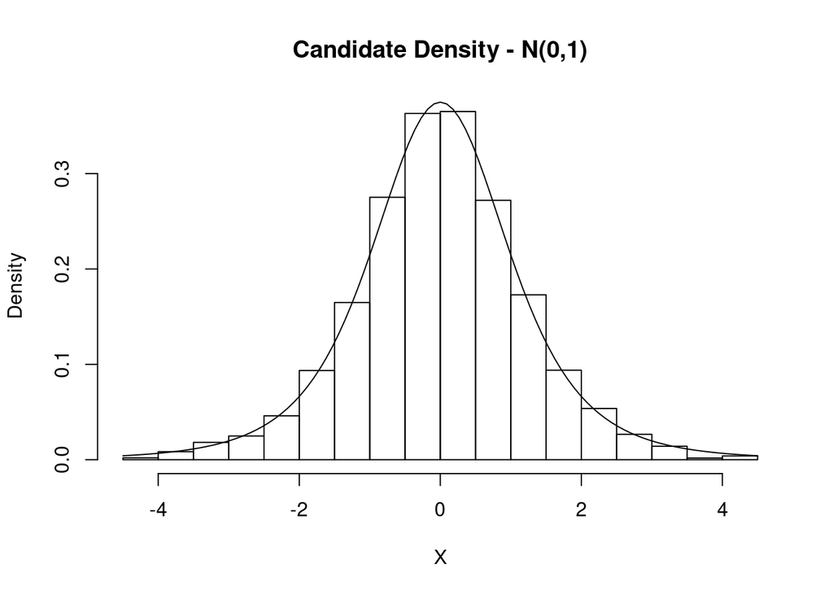

```r
# Get the vectors for the loop
  Accept <- 1
  X <- rep(runif(1),Nsim)

# Run the Loop
  for (i in 2:Nsim){
    ## Get the candidate from N(0,1)
     Y <- rnorm(n=1,mean=0,sd=1)
    ## (g(candidate)*q(X[i-1]))/(g(x[i-1])*q(candidate)
     rho <- (dt(Y,df=4)*dnorm(X[i-1],mean=0,sd=1))/
            (dt(X[i-1],df=4)*dnorm(Y,mean=0,sd=1))
    ## Accept Y with rho
      X[i] <- X[i-1] + (Y-X[i-1])*(runif(1)<rho)
    ## Acceptance rate
      Accept[i] <- (runif(1)<rho)
  }
  hist(X, freq=FALSE, main="Candidate Density - N(0,1)")
  curve(dt(x,df=4),add=T)
```

```r
  print(paste0("Acceptance Rate based on N(0,1) ",(sum(as.numeric(Accept)))/(Nsim-1)))
```

```
## [1] "Acceptance Rate based on N(0,1) 0.924338486769735"
```

```r
  print(paste0("Mean based on N(0,1) = ",mean(X)))
```

```
## [1] "Mean based on N(0,1) = 0.000931029058754721"
```

## (b) t with 2 degrees of freedom

```r
# Parameters
Nsim <- 50000

# Get the true distribution for comparison
  tdist <- rt(n=Nsim,df=4)
  print(paste0("True mean of t(4) is ,", mean(tdist)))
```

```
## [1] "True mean of t(4) is ,-0.0042723627168306"
```

```r
# Get the vectors for the loop
  Accept <- 1
  X2 <- rep(runif(1),Nsim)

# Run the Loop
  for (i in 2:Nsim){
    ## Get the candidate from t(2)
     Y <- rt(n=1,df=2)
    ## (g(candidate)*q(X[i-1]))/(g(x[i-1])*q(candidate)
     rho <- (dt(Y,df=4)*dt(X2[i-1],df=2))/
            (dt(X2[i-1],df=4)*dt(Y,df=2))
    ## Accept Y with probability rho
      X2[i] <- X2[i-1] + (Y-X2[i-1])*(runif(1)<rho)
    ## Acceptance rate
      Accept[i] <- (runif(1)<rho)
  }
  print(paste0("Acceptance Rate based on t(2) ",(sum(as.numeric(Accept)))/(Nsim-1)))
```

```
## [1] "Acceptance Rate based on t(2) 0.915698313966279"
```

```r
  print(paste0("Mean based on t(2) = ",mean(X)))
```

```
## [1] "Mean based on t(2) = 0.000931029058754721"
```

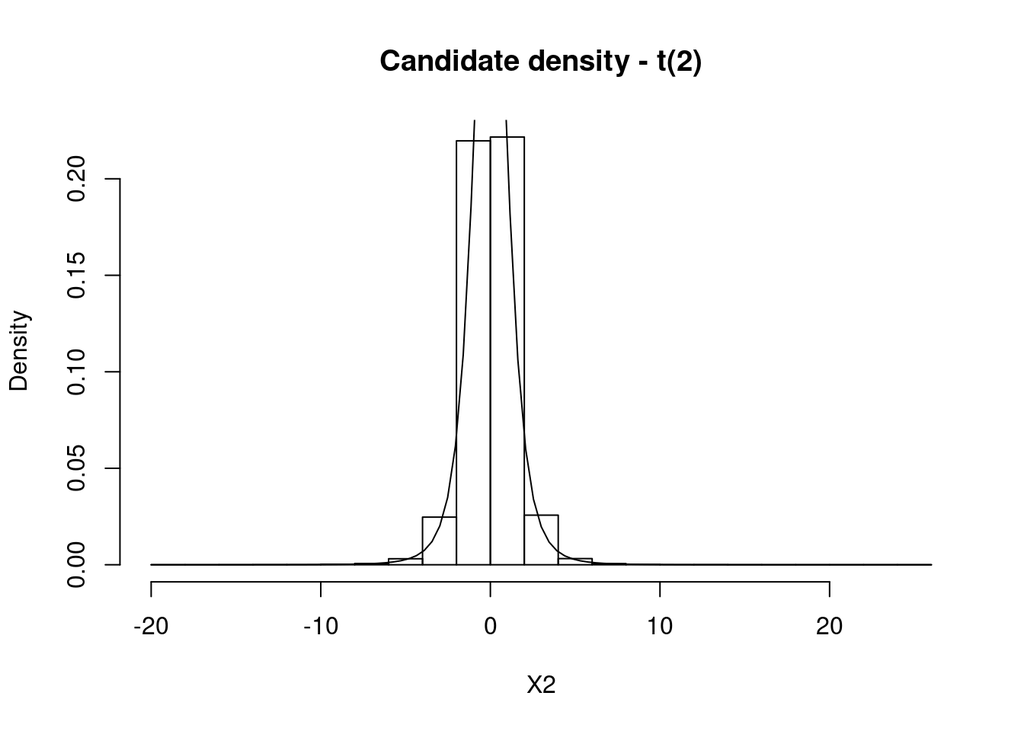

```r
  hist(X2, freq=FALSE, main="Candidate density - t(2)")
  curve(dt(x,df=4),add=T)
```

## (c) Compare

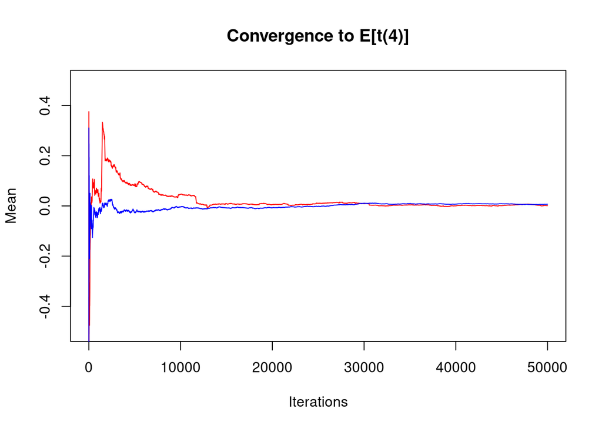

```r
mean.normcand <- cumsum(X)/1:Nsim
mean.t2 <- cumsum(X2)/1:Nsim

plot(mean.normcand, type='l',col='red',ylim=c(-0.5,0.5), main="Convergence to E[t(4)]",xlab="Iterations",ylab="Mean")
lines(mean.t2,col='blue')
```

# Problem 2

To find the $P(1\leq X \leq 4)$ we need to adjust the candidate density. Since it is bounded I will use a candidate density of $U[1,4]$. This will allow us to sum over $f(x)$ and find that $P(1\leq X \leq 4) \approx 0.29$

```r
# Set parameters
    Nsim <- 100000
    beta <- 2

# Set functions
  fx <- function(x){
    (4*x^2 *exp((-x^2/(beta^2))))/(beta^3*sqrt(pi))
  }

# Importance Sampling
  # Simulate values from U[1,4]
    gx <- runif(Nsim,1,4)
  # Get the density weight [f(x)/g(x)] - in this case g(x) is uniform so no need to divide.
    wX <- fx(gx)
  # Compute values of X
    X <- wX

    probability <- sum(X)/Nsim
print(paste0("The probability 1 < x < 4 for pdf f(x) is ", probability))
```

```
## [1] "The probability 1 < x < 4 for pdf f(x) is 0.290953988860302"
```

# Problem 3

Suppose the random variables X and Y both take on values in the interval (0,B). Suppose that the conditional densities are:
$$\begin{align*}
f(x|y) &= C(y)exp(-xy) \\
f(y|x) &= C(x)exp(-xy) \\
\end{align*}$$

It is the *amazing* property of Gibbs sampling that the joint distribution $f(x,y)$ only depends on the conditional distributions. It relies the fact for markov chains $X_t$ depends only on $X_{t-1}$. We can apply this directly to the equations above using the exponential distribution. 1. Generate an initial $x_1$, this can be anything but given the look of the distribution we can *guess* that the r command *rexp(1,1)* will give a resonable initial guess.

2. Evaluate $C(x_1)$
3. Generate $y_1 \sim C(x_1)\cdot Exp(-x_1)$
4. Generate $x_2 \sim C(y_1)\cdot Exp(-y_2)$
5. Repeate steps 3 and 4 for $t \in T$

I can demonstrate an example of this by letting $C(x)=x$ and $C(y)=y$ and $B=1$

```r
# Set parameters
  Nsim <- 1000

# Set Initial X_1 based on exponential distribution
  X0 <- rexp(n=1,1)
  X <- X0
# Set inital Y_1  (outside the loop cuz it is Y1)
  Y <- X0*rexp(n=1,X0)

# Run the loop
  for (i in 2:Nsim){
    # Sample X
      X[i] <- Y[i-1]*rexp(n=1,Y[i-1])
    # Sample Y
      Y[i] <- X[i-1]*rexp(n=1,X[i-1])
  }
```

# Problem 4

## (a)

In as much detail as you can, explain the concept of Rao-Blackwellization and why it’s helpful.

Rao-Blackwellization is a techinque used for variance reduction. It relies on the notion that the sufficient statistic, $\theta$, contains enough information about a distribution, $f$ that will allow you to sample from it. Since the sufficient statistic is typically simpler, sampling from $\theta$ will result in a lower variance when used with a conditional function, $g(x|\theta)$, that is an estimator for $f$ i.e. $Var(E[g(x)|\theta])\leq Var(g(x))$

## (b)

$$\begin{align*}
log(X) &\sim N(\mu,\sigma^2) \\
X &\sim lognormal(0,1) \\
log(Y) &\sim 9 + 3\cdot log(X) + \epsilon \\
\epsilon &\sim N(0,1) \\
log(W) &\sim N(\mu,\sigma^2) \implies E(W) = exp(\mu + \sigma/2)
\end{align*}$$
Estimate $E(\frac{Y}{X})$.

Compare the performance of the standard Monte Carlo estimator and the Rao-Blackwellized estimator of this expectation.

I honestly can’t figure this one out. So I did my best.

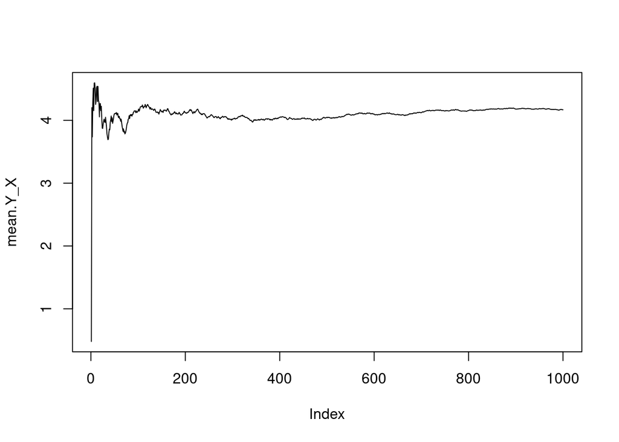

```r
# Parameters
  mu <- 0
  var <- 1
  sd <- sqrt(var)
  Nsim <- 1000

# Function
  FY <- function(x,e){
    (9 + 3*(x) + e)
  }

# Generate X values
  logX <- rlnorm(Nsim,mean=mu,sd=sd)
  X <- exp(logX)

# Generate e values
  E <- rnorm(Nsim,0,1)

# Evaluate Y
  logY <- FY(logX,E)
  Y <- logY

# Evaluate Y/X
  Y_X <- Y/X

# Mean
  mean.Y_X <- cumsum(Y_X)/(1:Nsim)
  plot(mean.Y_X, type='l')
```

# Problem 5

Explain what the Bootstrap and Jackknife methods are to Botts, James Botts.

The term Bootstrap comes from the phrase “Pick yourself up from your bootstraps” meaning that you need to succeed in your endeavors without someone needing to “help you up”. The method follows from this because it takes a small amount of information and compounds itself so as to accomplish much more!

To explain bootsrapping lets say you have some patients with a rare disease you’ve never seen before. You are pretty sure that the disease has the unforunate side effect of making the patients’ nose hair grow very long. You’ve measured the nose hairs of your 10 patients, but inorder to make any conclusions you need to figure out what the average nose hair length is for someone with the disease. You don’t think there is anything special about the patients who came to see you other than the diesase, so they are probably a reasonably representative sample of anyone with the affliction. So you imagine “what if doctors offices all around the country are noticing the same trend?”

You apply the bootstrap by sampling the nose hair length of your 10 patients N times. In statistics this is called, “sampling from the empirical distribution function” which just means that you’re giving every one of your patients equal importance in the data. This gives you N samples of 10 patients, all with the same disease and weirdly long nose hair. The following data shows 3 samples of the original 10 patients, where each column represents one sample of 10 patients, and each number is the length of a patients nose hair (in centimeters).

```r
# The nose hair length (in centimeters) for your 10 patients.
original.data <- c(12,16,15,12,10,9,11,10,13,11)
all.data <- original.data %>% as.data.frame()
vector.data <- original.data

for (i in 2:1000){
  all.data[,i]<- sample(original.data,10,replace=TRUE)
  vector.data <- c(vector.data,all.data[,i])
}

as.matrix(all.data[1:3])
```

```
##        . V2 V3
##  [1,] 12 12 10
##  [2,] 16 16 10
##  [3,] 15  9 10
##  [4,] 12 12 12
##  [5,] 10 10 11
##  [6,]  9 12 10
##  [7,] 11 11 12
##  [8,] 10 16 11
##  [9,] 13 13 16
## [10,] 11 10 10
```

Now that you have some more observations, you can start trying to learn more about the data. You may be interested to know what the average nose hair length is for someone with the disease. What you can do is take the average of each of the sample populations (the average of the 10 patients from each doctors office). This will give you a much better idea of what the true population mean is, since you have a larger sample. You can see, in the graph below that the average for all the samples follows something close to a normal distribution!

[figure not shown]

```r
average.nosehair <- all.data %>% summarise_all(mean)
average.nosehair <- as.vector(t(average.nosehair))
hist(average.nosehair, main="Average Nose Hair Length for 100 Doctors Offices")
```

```r
(sum(average.nosehair<=11)/1000)*100
```

```
## [1] 8.7
```

It is clear that the bootstrap can add power to a small sample of data but you must be careful when using it. You should be sure that the sample data are representative of the whole. It is also difficult to use the bootstrap when the observations are correlated. For example, if (rather than 10 patients) the data above was from 1 patient taken over 10 periods of time. For instances such as this we can emply the jackknife bootstrap method!

Rather that sampling randomly from the population, the jackknife *cuts* one observation from the sample. One can consider the sample (1,2,3,4,5,6). The jackknife takes 6 samples removing one each time:
$$\begin{align*}
\text{Sample 1:} && 2,3,4,5,6 \\
\text{Sample 2:} && 1,3,4,5,6 \\
\text{Sample 3:} && 1,2,4,5,6 \\
\text{Sample 4:} && 1,2,3,5,6 \\
\text{Sample 5:} && 1,2,3,4,6 \\
\text{Sample 6:} && 1,2,3,4,5 \\
\end{align*}$$

The jackknife is better at handling correlated data, intuitively time series. If, in the previous example, we were measuring one patient over 10 time intervals, the length of the nose hair in one period would certainly be related to the length in the previous period. Now, this means we can’t take as many samples as we could with the bootstrap so typically we would need a larger starting sample.

One of the primary limitations of the jackknife is that is isn’t good at measuring data that doesn’t vary much when you remove one observation. The cannonical example of this is the median. Removing on value from a set of observations will only change the median twice (since it will be before or after the median). Take the samples above, the median for samples 1,2, and 3 is 4. The median for samples 4,5, and 6 is 3.It is clear that this will not give us much more information about the data!

# Problem 6

One of the homework problems I had you do was to illustrate that the bootstrap isn’t a very good way of estimating $\theta$, for the $Unif(0,\theta)$ distribution. Show the same thing for the mean of a cauchy distribution.

First lets think about it intuitively. Bootstrap relies on sampling from a sample over and over so the sample must be a pretty good representation of the data. BUT the cauchy distribution is the Wile E. Cayote of distributions it doesn’t have a stable mean or variance. So it makes sense that the bootstrap wouldn’t really work.

To show this, I run a bootstrap with 10,000 iterations estimating the mean of the sample of size 10 simulated from a cauchy distribution. Note that this didn’t seem to work well for the base cauchy so I used *rcauchy(7)*. I then do a histogram of the simulated means. Notice that this is clearly not normaly distributed as we would normally require from the bootstrap. Since the means are not normally distributed around any particular value, we can not apply the central limit theorm and get a good estimate of the mean.

```r
Nsim <- 10000

# Get the initial distribution
  cauchy.sample <- rcauchy(10,7)
    sample <- round(cauchy.sample,2) %>% toString()
    print(paste0("We are going to sample from 10 observations (derived from a cauchy distribution:",sample))
```

```
## [1] "We are going to sample from 10 observations (derived from a cauchy distribution:11.44, 6.99, 6.99, 6.6, 6.55, 7.21, 11.27, -13.71, 6.86, 8.06"
```

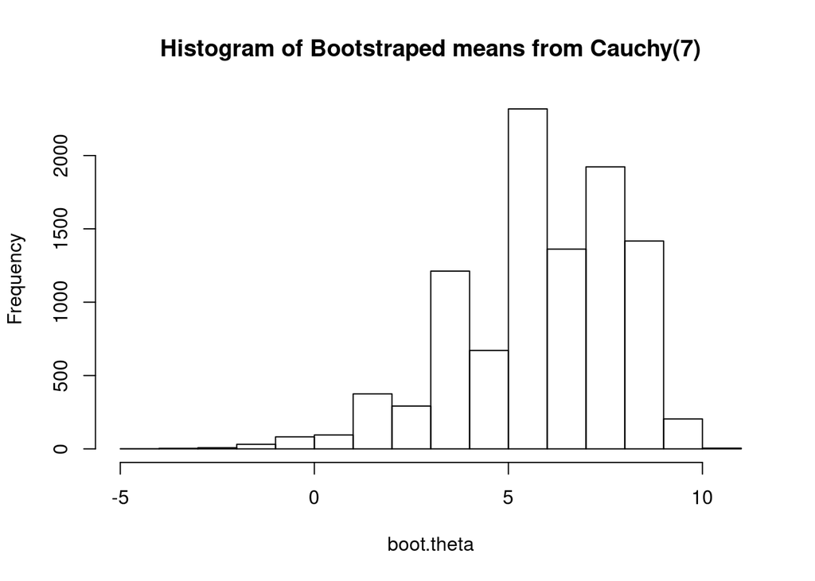

```r
# Sample from it with the Bootstrap Bill Turner
  boot.theta <- c()
  for (i in 1:Nsim){
  bootstrap <- sample(cauchy.sample,size=10,replace=TRUE)
  boot.theta[i] <- mean(bootstrap)
  }
  boot.mean <- cumsum(boot.theta)/(1:Nsim)

  hist(boot.theta, main="Histogram of Bootstraped means from Cauchy(7)")
```

# Problem 7

Consider the stochastic differential equation (SDE):
$$dX(t) = f(X(t))dt+g(X(t))dW(t)$$

What is the Euler-Marumaya solution to such an equation?

Basically what the Euler-Marumaya *approximation* does is to discretize the time intervals $(dt)$ and simulate the random *noise*, $W(t)$. I’ll define this numerically this out to the best of my ability. Let $0<s<t<T$ be time increments from [0,T], the time span of X. Let there be N discrete time increments, $\tau_i, \cdots \tau_N$, on T. So we have $dt =T/N$. So we can plug these into the SDE to get:
$$X_i = X_{i-1} + f(X_{i-1})\cdot (T/N)+ g(X_{i-1})\cdot (W(\tau_i)-W(\tau_{i-1}))$$

Now with a computer we can simulate N values of $X_i$ using a random number generator for $W(\tau_i)-W(\tau_{i-1})$ since the difference is an independent random variable.

I’ll demonstrate this with an example (Black Scholes) with $f(x) = \lambda X$ and $g(X)= \mu X$. So we have:

$$\begin{align*}
\text{Euler-Marumaya Approx:} && X_i &= X_{i-1} + \lambda X_{i-1}(T/N) + \mu X_{i-1} (W(\tau_i)-W(\tau_{i-1})) \\
\text{Black-Scholes Solution:} && Y_i &= Y_{0}e^{(\lambda-\mu^2/2)}t+\mu W(t) \\
\end{align*}$$

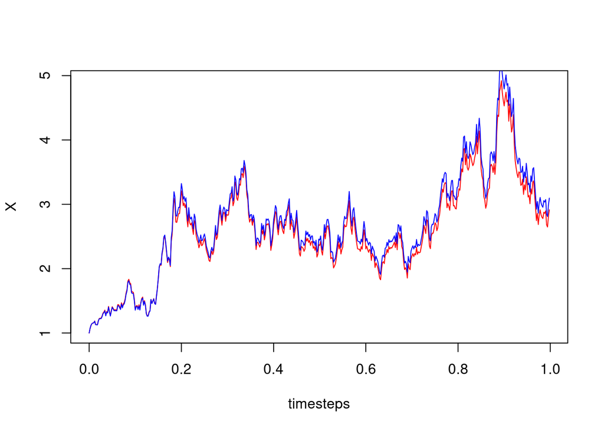

```r
# Set the paramters
    Nsim <- 500
    X <- rep(1,Nsim)
    Time <- 1
    dt <- (Time/Nsim)

    lambda = 1
    mu = 1

# Empty vetors fro the loop
    timesteps <- seq(0,Time,dt)[1:Nsim]
    W <- rep(0,Nsim)

# Loop the loop and pull and your shoes are looking cool
  for (i in 2:Nsim){
    # Get your random noise
      dW <- rnorm(n=1,mean=0,sd=sqrt(dt))
    # X
      X[i] <- X[i-1] + lambda*dt*X[i-1] + mu*dW*X[i-1]
      W[i] <- W[i-1] + dW
  }
truesolution = X[1]*exp((lambda-mu^2/2)*timesteps + mu*W)

# Plot
  plot(timesteps,X, col = 'red',type='l')
  points(timesteps,truesolution, col='blue',type='l')
```

Notice in the plot above how the red dots generated from the Euler-Marumaya approximation are very close to the ‘true’ solution derived from Black Scholes. The intuition as to why this holds is fairly strightforward. The integration is definitionally a sort of Reiman sum with smaller and smaller increments. What the program allows us to do is take very ‘small’ increments and therby evaluate the integral (the change) over the increment. Then all we need to do is add this change to the total and that gives us the level following the change. The other part of this revolves around the random variable $W(t)$, the “noise”. Now, the noise is defined as an independent random variable, if this were not the case the approximation wouldn’t work. But because we are able to simulate the noise by generating an indepdent random variable, we can compute the (discretized) $dW$ term, even though we can not actually differentiate it!

The two types of convergence for SDEs are aptly named “strong” and “week” convergence. Strong convergence is the average error between the Eular-Marumaya approximation and the actual solution. Weak convergence is the difference between the average of the two. The sequences are said to converge with power $\gamma$ if the difference is less than the size of the time step $\tau^{\gamma}$. Below I’ve expressed this mathematically, but you can think of it like a limit theorem, where $\tau$ is the $\epsilon$ and we are curious if the approximation converges to the true value.

From above I denote the solution from the EM approximation as $X_i$ and the black scholes solution $Y_i$.
$$\begin{align*}
\text{Strong Convergence:} && E|Y_i-X_i| \leq \tau^{\gamma}\\
\text{Weak Convergence:} && |E(Y_i)-E(X_i)|\leq \tau^{\gamma} \\
\end{align*}$$